# Machine Learning for Trading with an Extended Case Study in R and Stan

updated 16 November 2017

## Introductions

## *Who is this Guy ?*

**Brian Peterson:**

- quant, author, open source advocate
- [DV Trading](http://dvtrading.co) Partner | Head Trader | Automated Trading Strategies
- Senior Lecturer (Part-Time), University of Washington [Computational Finance and Risk Management](http://depts.washington.edu/compfin/)
- author or co-author of over 10 packages for using R in Finance
- organization admin for [**R**](https://github.com/rstats-gsoc/)'s participation in [Google Summer of Code](https://summerofcode.withgoogle.com/)

**Proprietary Trading:**

- proprietary or principal traders are a specific "member" structure with the exchanges
- high barriers to entry, large up-front capital requirements
- many strategies pursued in this structure have capacity constraints
- benefits on the other side are low fees, potentially high leverage
- money management needs to be very focused on drawdowns, leverage, volatility

## So what is Machine Learning?

- after Artificial Intelligence models failed to produce human-like intelligence
- Machine Learning was adopted as the term to include a huge range of (mostly) non-parametric computational inference models
- the goal is to provide inference from data
- lives at the intersection of computer science and statistics

see:

- Domingos (2015) *The Master Algorithm*
- Efron & Hastie (2016) *Computer Age Statistical Inference*

for book-length treatments.

## Data and Features

## So it's all about the data?

- market data capture going from ~100GB/day to ~1+TB/day as more information sent by exchanges
- many vendors, including huge players like Reuters and IBM, are providing additional parsed data sources
- top users of ML in trading are collecting, curating, and cultivating rare or private data sources
- now common to have tens to hundreds of additional descriptive time series in addition to market data

https://xkcd.com/1838/<sup>1</sup>

## What about the Features?

- how do we go from descriptive to predictive?
- the raw data is usually not the main feature in time series prediction
- feature selection (Guyon and Elisseeff 2003) ranks and filters multiple possible features
- it is often better to first engage in pro-active feature engineering:
  - transformation of data to regularize scale, variation
  - coding of data into categorical or integer states
  - adding features that are indicative of the objective
  - using extra models for things like seasonality or colinearity

## About the Models

## Rules Engines

- rules created by experts have largely fallen out of favor (*or have they?*)
- knowledge engineering and expert systems enjoyed a brief ascendancy in the 1980's
- notably before computers were fast enough to employ statistical approaches
- many of the most successful users of ML spend significant time and money crafting features from data
- perhaps knowledge encoded as features is the most important legacy of the expert systems
- Decision Tree R Packages: [rpart](http://cran.r-project.org/web/packages/rpart/index.html) [party](http://cran.r-project.org/web/packages/party/index.html) [randomForest](http://cran.r-project.org/web/packages/randomForest/index.html)

## Optimization

- almost all machine learning has its roots in optimization
- many algorithms use optimization solvers or parts of optimization solvers
- optimization is also valuable in this context because it is one of the most common ML use cases
- for overviews of (primarily) convex optimization see the Simon's Institute talks by Ben Recht (2013a, (2013b))
- global stochastic models can handle non-smooth objectives, e.g.
  - Particle Swarms (Kennedy 2011), e.g. pso
  - Simulated Annealing (Kirkpatrick et al. 1983), e.g. genSA
  - Genetic Algos like Differential Evolution (Price, Storn, and Lampinen 2006, Zhang and Sanderson (2009)), e.g. DEoptim

… and *learn* or adapt as they gather more data

## Gradient Descent

- gradient descent is the preference to move towards a local minima
- used widely in solving optimization problems
- the famous Perceptron (Rosenblatt 1958) is a gradient descent algorithm (and also the original neural network)
- information on Momentum for gradient descent in Goh (2017)
- [policy gradients](http://www.scholarpedia.org/article/Policy_gradient_methods) are formed when you add parameters to gradient descent, and update optimal parameters as more data is examined
- policy gradients are the key mechanism utilized to construct reinforcement learning agent based models
- see packages [ReinforcementLearning](https://cran.r-project.org/web/packages/ReinforcementLearning/), MDPtoolbox, and gym

## Back Propagation

- backpropagation is the adjustment of previously established views or connections based on how new data differs from expectations
- related to policy gradients and gradient descent,
- the most famous models employing backpropagation are neural networks
- 'deep learning' is a neural network with more layers, requiring bigger computers and more data
- one of the oldest true 'learning' approaches as the model adapts itself (Chauvin and Rumelhart 1995, Horikawa, Furuhashi, and Uchikawa (1992))
- host of different neural network flavors, implemented in neuralnet, [keras](https://rstudio.github.io/keras/), [tensorflow](https://tensorflow.rstudio.com/)

## Evolution (Crossover & Mutation)

- all stochastic optimizers are to some degree population based
- evolutionary algorithms adopt this language from biology
- features critical to 'learning' optimizers are crossover and mutation
- crossover is the mixing of features from more successful trials (Spears and others 1992, Spears et al. (1993))
- mutation randomizes features (even if successful) to avoid local minima
- look at global solvers such as DEoptim or pso

## Similarity

- similarity between training set and sample used to draw inferences
- applicable to both Euclidian and non-Euclidian feature spaces
- after pairwise similarity methodology is set, no need for access to the features themselves
- applied to regression, classification, and ranking (Chen et al. 2009)
- [k-means clusters](https://stat.ethz.ch/R-manual/R-devel/library/stats/html/kmeans.html), [SVM](https://cran.r-project.org/web/packages/e1071/) models, [kernel](https://cran.r-project.org/web/packages/KernSmooth/) models all used to build similarity models

## Probabalistic Inference

- relationships between variables may often be known only with a certain probability
- state transitions also occur with a certain observable probability even if the underlying causes are unknown
- inference from these probabilities is the core of Monte Carlo, Bayesian methods (Cooper 1990, Neal (1993))
- inherently computationally intensive in ways that some earlier learning approaches were not
- see [Stan](http://mc-stan.org) (and [rstan](https://cran.r-project.org/web/packages/rstan/))

## Compute Implications

- choose a technology stack to build on
  - R, python
  - libraries such as TensorFlow, AzureML, mlr, scikit-learn
  - the heavy lifting is done with compiled code
  - cluster architecture (OpenStack, AWS, Azure, Google Compute)
  - use specialized hardware where appropriate (e.g. GPU, TPU, ASIC)
- normalize all data access and metadata
  - specialized time series databases (e.g. InfluxDB, Timebase, OneTick, kdb, Streambase)
  - catalog all the data, version it
- build a process for continuously evaluating models (Breck et al. 2016)

## Getting It Wrong

## Evaluating Overfitting in Machine Learning

Classical measures:

- specialized *t*-tests for ML algorithms
- cross-validation (but this makes the *t*-test challenging)
- *p*-value (but subject to *p*-hacking (Head et al. 2015))
- multiple-hypothesis testing (beware of false discovery rate (Efron and Hastie 2016, Ch. 15))
- mean squared forecast error (MSFE, RMSE)
- resampled errors (bootstrap, permutation tests, etc.)

ML-specific measures (Japkowicz and Shah 2011):

- Confusion Matrix
- Receiver Operating Characteristic (ROC) plots/stats or the related Cost Curves

*Make sure that you can inspect the choices your model is making!*

## Detecting Overfitting in Backtests

Multiple tests focused on overfitting of backtests also exist:

- **Walk Forward Analysis** : Pardo (2008) in quantstrat
- **Equity Curve Monte Carlo** : Tomasini and Jaekle (2009) in blotter
- **Round Turn Trade Monte Carlo** : Peterson (2017) in quantstrat
- **White's Reality Check** : from White (2000) and Hansen (2005) in [ttrTests](https://www.r-bloggers.com/tag/ttrtests)
- **k-fold cross validation** : randomly divide the sample of size \(T\) into sequential sub-samples of size \(T/k\). (Hastie, Tibshirani, and Friedman 2009)
- **CSCV sampling** (combinatorially symmetric cross validation): "generate \(S/2\) testing sets of size \(T/2\) by recombining the \(S\) slices of the overall sample of size \(T\) ". (Bailey et al. 2014, 17) in pbo
- **Multiple Hypothesis Testing** looks at Type I vs Type II error in evaluating backtests and at appropriate haircuts based on these probabilities. (Harvey and Liu 2015 ) in quantstrat

## Using Machine Learning in Trading

*A big computer, a complex algorithm and a long time does not equal science*. - Robert Gentleman

## Regression

- regression results may be the most common uses of machine learning
- you want the algorithm to estimate the value (mean/median), slope, etc. of some variable
- you may do this directly (e.g. [logistic regression](https://stat.ethz.ch/R-manual/R-devel/library/stats/html/glm.html), Bayesian regression via [Stan](https://cran.r-project.org/web/packages/rstan/), [Random Forest](https://cran.r-project.org/web/packages/randomForest), [Boost](https://cran.r-project.org/web/packages/mboost))
- or indirectly (MCMC, gradient descent, [state space model](https://cran.r-project.org/web/packages/forecast/), optimization model with the correct objective)
- in many cases, simpler regression models (e.g. dlm, [ridge regression](https://cran.r-project.org/web/packages/penalized), [LASSO](https://cran.r-project.org/web/packages/lars)) may do just as well

## Optimization

- not just a model feature, optimization is often the end goal
- consider whether simpler linear/quadratic/gradient optimizers will work – less model risk
- optimizer parameters for global optimizers can have huge impacts on model outputs and computation
- many problems may be recast as optimization problems:
  - capital allocation, see PortfolioAnalytics
  - risk management, see PortfolioAnalytics and PerformanceAnalytics
  - adaptive parameters
  - (optimal) process control, see gym and MDPtoolbox

## Classification / Clustering

- separation of observations into groups or states is classification or clustering (Japkowicz and Shah 2011)
- many ML models are used as classifiers
- proceeding from simple models is usually advisable
- key goal is typically to *label* the observed data or state
- so that some other model can take action based on that label/state
- common classification uses:
  - volatility regimes, e.g. [Markov Switching GARCH](https://github.com/keblu/MSGARCH)
  - country/sector/volatility clustering
  - bull/bear market classification
  - trending/consolidating market

## Composite Models

- lots of little models
- ensembles, boosting, weak learners
- in trading, this means mostly feature engineering
- or combining weak alpha trading models
- Worldquant (Tulchinsky 2015), Kepos (Carhart/Litterman), Jump, Renaissance, Bridgewater, Citadel, others all doing this to one degree or another

*Doing this well takes scale!*

## Model Discovery

- use the ML model to *discover* trading strategies
- given market data, build trading rules
- the 'Holy Grail' of ML in trading

*Like the Grail, mostly a myth*

## Machine Learning in Trading

- "targeted" machine learning is all around us (e.g. voice recognition, face recognition)
- some of the most spectacular advances for large scale ML have been games (Jeopardy, Chess, Go, DOTA2)
- those wins had huge custom built computers behind them, doing *online* ML
- most uses of ML in Trading are *offline*,
  - models trained on large data, clusters, GPU's, TPU's
  - model parameters then fixed for 24 hours or more
- or use a simplified *online* model that updates state but does not refit model parameters
- feature engineering is what makes models work
- many good features and data sets make model 'discovery' possible
- focus on curating your data, building features
- with enough data, models, and features, you have broad choice of algorithms

## Case Study

## Digression: Google Summer of Code

- [Google Summer of Code](https://summerofcode.withgoogle.com/) is an annual program
- students write open source code for the summer with the assistance of project mentors
- students compete for slots each summer that take the place of an industry internship
- students get paid a [stipend](https://developers.google.com/open-source/gsoc/help/student-stipends) by Google
- [**R**](https://github.com/rstats-gsoc/) has participated for 12 of the 13 years the program has existed
- several student projects in **R** GSoC each year are Finance and/or Machine Learning related:
  - Rcpp
  - financial graphics
  - evaluating estimation errors for performance and risk
  - porting matlab code from Dowd, Meucci, others
  - [research replication](https://www.researchgate.net/publication/319298241_Research_Replication)
  - extending machine learning libraries like mlr, [Keras](https://github.com/rstudio/keras), Stan, Tensorflow, and others

## High Frequency Data

- large
- noisy
- non-stationary
- 10's to 100's of GB of data per day per market
- millions to billions of observations per instrument
- time-alignment issues across markets and data sources

## Implementation: Rmarkdown

- we extensively use *rmarkdown*(Xie 2017) for repeatable, compileable documents
- write documentation and code together in one document
- and research and production reports
- we find it easier to use than the older [Sweave](https://support.rstudio.com/hc/en-us/articles/200552056-Using-Sweave-and-knitr)
- well supported for development and testing via RStudio
- I use it extensively for presentations (like this one! code available upon request)

## Implementation: Time Series Data

- we use *xts*(Ryan, Ulrich, and Bennett 2017) for time series data in **R**
- *plot.xts* written by Ross Bennett, is massively faster than *ggplot2*(Wickham, Chang, and RStudio 2016)

Critical features for dealing with time series:

- easy merging of data by time/date index
- easy subsetting using [ISO-8601](https://xkcd.com/1179/)
- can handle billions of rows, unlike the *tidyverse*(Wickham and RStudio 2017)
- the Tayal replication is a *small* study, and used 101 M rows of data, ~10GB uncompressed
- training windows on individual instruments contained several million rows
- feature processing reduced dimensionality to ~10k features per day per symbol

## Digression: History of Monte Carlo analysis

- Laplace was the first to describe the mathematical properties of sampling from a distribution
- Mahalanobis extended this work in the 1930's to describe sampling from dependent distributions, and anticipated the block bootstrap by examining these dependencies
- Monte Carlo simulation was developed by Stan Ulam and John von Neumann (with computation by Françoise Ulam) as part of the hydrogen bomb program in 1946 (Richard Rhodes, **Dark Sun**, p.304)
- computational implementation of Monte Carlo simulation was constructed by Nicholas Metropolis on the ENIAC and MANIAC machines
- Metropolis was an author in 1953 of the prior distribution sampler extended by W.K Hastings to the modern Metropolis-Hastings form in 1970
- Maurice Quenouille and John Tukey developed 'jackknife' simulation in the 1950's
- Bradley Efron described the modern bootstrap in 1979

## Hidden Markov Models

- many processes are only partially observable
- inputs are known, but may be incomplete
- outputs are observable, but may be probabilistic and/or noisy
- Hidden Markov Models combine a discrete state model with an output or observation model
- transitions between states are governed by a 'chained' Markov state
- probability of being in one state or another can be computed at each observation

## Implementation: Stan

- [Stan](http://mc-stan.org/) is a domain specific language (DSL) for doing Bayesian inference
- named for Stan Ulam
- given an unknown quantity \(\phi\) sample from a probability distribution with a state transition matrix
- in theory (potentially given infinite time and a sufficiently good guess), the sample distribution will converge on the unknown distribution
- the primary sampling method used in Stan is called *Hamiltonian* Monte Carlo
- the Hamiltonian sampler(Neal 2011) will typically perform better than the older, simpler Gibbs sampler or the Metropolis-Hastings sampler for high-dimensional problems or problems with multiple parameters

## Implementation: Stan Models

- all Stan models consist of a specification of the *data*, a set of *parameters*, and a *model* which describes the sampling and transition matrix

```stan
data {
  int<lower=1> T;                   // number of observations (length)
  int<lower=1> K;                   // number of hidden states
  real x_t[T];                      // observations
}

parameters {
  // Discrete state model
  simplex[K] p_1k;                  // initial state probabilities
  simplex[K] A_ij[K];               // transition probabilities
                                    // A_ij[i][j] = p(z_t = j | z_{t-1} = i)

  // Continuous observation model
  ordered[K] mu_k;                  // observation means
  real<lower=0> sigma_k[K];         // observation standard deviations
}
```

## Implementation: HMM

- the model draws from a generative path using the transition probabilities

```r
runif_simplex <- function(T) {
  x <- -log(runif(T))
  x / sum(x)
}

hmm_generate <- function(K, T) {
  # 1. Parameters
  p_1k <- runif_simplex(K)
  A_ij <- t(replicate(K, runif_simplex(K)))
  mu_k <- sort(rnorm(K, 10 * 1:K, 1))
  sigma_k <- abs(rnorm(K))

  # 2. Hidden path
  z_t <- vector("numeric", T)

  z_t[1] <- sample(1:K, size = 1, prob = p_1k)
  for (t in 2:T)
    z_t[t] <- sample(1:K, size = 1, prob = A_ij[z_t[t - 1], ])

  # 3. Observations
  x_t <- vector("numeric", T)
  for (t in 1:T)
    x_t[t] <- rnorm(1, mu_k[z_t[t]], sigma_k[z_t[t]])

  list(x_t = x_t, z_t = z_t,
       theta = list(p_1k = p_1k, A_ij = A_ij,
                    mu_k = mu_k, sigma_k = sigma_k))
}
```

- note that this model draws from a Gaussian prior, and is controlling the transition matrix to get differentiation
- see https://github.com/luisdamiano/stancon18/ for a full tutorial on HMM in Stan

## How to make useful predictions from features?

*[…] some machine learning projects succeed and some fail. What makes the difference? Easily the most important factor is the features used.* (Domingos 2012)

A plain **HMM** is a probabilistic learner of the unobserved dynamics behind a sequence of discrete features. The Tayal **HHMM** maps the features and the corresponding learned states into bull and bear markets by establishing a hierarchy.

**The strengths of the features**:

- **Underlying theory**: representative of beliefs about how markets work (interactions between price and volume)
- **Statistical properties**: captures non-linearities in a simple, parsimonious, and tractable way
- **Noise reduction**: by discretization
- **Computational complexity**: improved by reducing data set size
- **Empirical support**: when applied on real data, results are consistent with empirical evidence

We test the model out of sample. After one feature (a "zig-zag") ends, we predict the next state. We buy one unit in bull states and sell one unit in bear states.

## Hierarchical Hidden Markov Model

### **Bayesian Hierarchical Hidden Markov Models applied to financial time series** (Damiano, Peterson, and Weylandt 2017) based on **Regime Switching and Technical Trading with Dynamic Bayesian Networks in High-Frequency Stock Markets** (Tayal 2009)

**Problem**: predicting price trends systematically in a profitable way

**Stylized Facts**:

- Market behavior is complex and partially unknown
- Non-linear interactions between price and volume
- Multi-resolution: short-term trends within long-term trends
- High-frequency: noisy and large data sets need fast online computations

**A Proposal**: ensemble of statistical and machine learning techniques

1. Create intermediate indicator variables
2. Combine them into discrete features using technical analysis rules
3. Build a hierarchy to link all the features in a logical way
4. Apply clustering with Markovian memory

## Case Study Feature Detail

**(1)** Identify local extrema, where \(e_n\) is the price at the extreme.

**(2)** Create intermediate variables \(\nu, \ \tilde{\nu}\) and features \(f_n^0\) direction, \(f_n^1\) price trend, \(f_n^2\) volume trend.

\[ f_n^0 = \begin{cases} +1 & \text{if $e_n$ is a local maximum (positive zig-zag)} \\ -1 & \text{if $e_n$ is a local minimum (negative zig-zag),} \\ \end{cases} \]

\[ f_n^1 = \begin{cases} +1 & \text{if $e_{n-4} < e_{n-2} < e_{n} \wedge e_{n-3} < e_{n-1}$ (up-trend)} \\ -1 & \text{if $e_{n-4} > e_{n-2} > e_{n} \wedge e_{n-3} > e_{n-1}$ (down-trend)} \\ 0 & \text{otherwise (no trend).} \end{cases} \]

\[ \nu_n^1 = \frac{\phi_n}{\phi_{n-1}}, \quad \nu_n^2 = \frac{\phi_n}{\phi_{n-2}}, \quad \nu_n^3 = \frac{\phi_{n-1}}{\phi_{n-2}}, \quad \tilde{\nu}_n^j = \begin{cases} +1 & \text{if $\nu_n^j - 1 > \alpha$} \\ -1 & \text{if $1 - \nu_n^j > \alpha$} \\ 0 & \text{if $|\nu_n^j - 1| \le \alpha$}, \\ \end{cases} \]

**(3)** Combine into 18 meaningful features using the following table. They will be linked hierarchically by the model.

| Feature | Zig-zag | Price trend | Volume trend | Market State | Feature | Zig-zag | Price trend | Volume trend | Market State |
| --- | --- | --- | --- | --- | --- | --- | --- | --- | --- |
| \(U_{1}\) | Up +1 | Up +1 | Strong +1 | Bull | \(D_{1}\) | Dn -1 | Up +1 | Weak -1 | Bull |
| \(U_{2}\) | Up +1 | Dn -1 | Strong +1 | Bull | \(D_{2}\) | Dn -1 | Dn -1 | Weak -1 | Bull |
| \(U_{3}\) | Up +1 | Up +1 | Indet 0 | Bull | \(D_{3}\) | Dn -1 | Up +1 | Indet 0 | Bull |
| \(U_{4}\) | Up +1 | No 0 | Strong +1 | Bull | \(D_{4}\) | Dn -1 | No 0 | Weak -1 | Bull |
| \(U_{5}\) | Up +1 | No 0 | Indet 0 | Local | \(D_{5}\) | Dn -1 | No 0 | Indet 0 | Local |
| \(U_{6}\) | Up +1 | No 0 | Weak -1 | Bear | \(D_{6}\) | Dn -1 | No 0 | Strong +1 | Bear |
| \(U_{7}\) | Up +1 | Dn -1 | Indet 0 | Bear | \(D_{7}\) | Dn -1 | Dn -1 | Indet 0 | Bear |
| \(U_{8}\) | Up +1 | Up +1 | Weak -1 | Bear | \(D_{8}\) | Dn -1 | Up +1 | Strong +1 | Bear |
| \(U_{9}\) | Up +1 | Dn -1 | Weak -1 | Bear | \(D_{9}\) | Dn -1 | Dn -1 | Strong +1 | Bear |

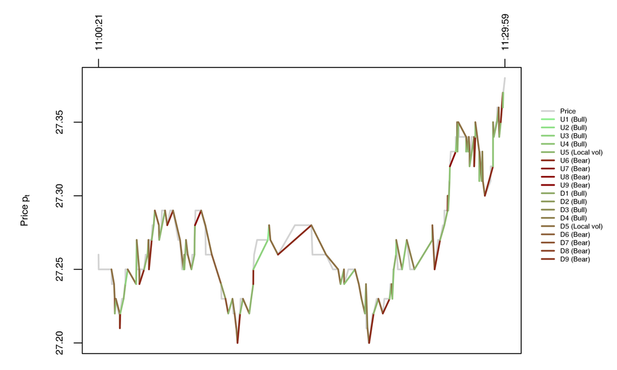

Features extracted from TSE:G 2007-05-11 11:00:00/2007-05-11 11:30:00.

## Results

Back tested on 12 stocks, 17 days, 7 configurations: \(12 \times 17 \times 7 = 1,428\) out of sample daily returns.

- For most stocks, HHMM outperforms buy & hold (B&H).
- Returns virtually uncorrelated with B&H.
- Sometimes HHMM offers less variance than B&H (further research needed).

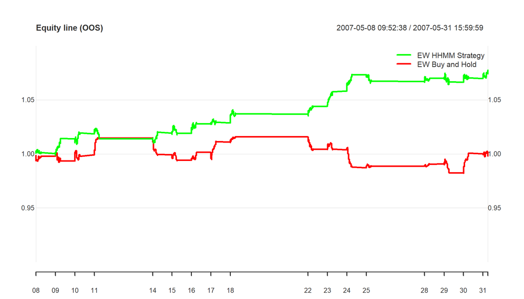

## Per-Instrument Results

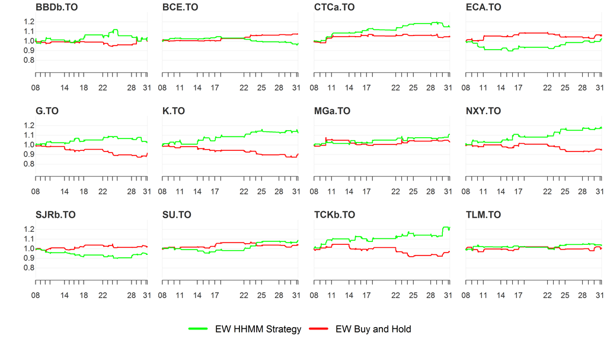

## Thanks

*Thank You for Your Attention*

Thanks to Luis Damiano for his work in GSoC2017, my team, and my family, who make it possible.

©2017 Brian G. Peterson brian@braverock.com

This work is licensed under a [Creative Commons Attribution 4.0 International License](http://creativecommons.org/licenses/by/4.0/)

Code to apply the techniques discussed here may be found in the *mlr*, *TensorFlow*, *rstan*, *blotter*, *quantstrat*, *PerformanceAnalytics*, *PortfolioAnalytics*, and other **R** packages.

All views expressed in this presentation are those of Brian Peterson, and do not necessarily reflect the opinions or policies of DV Trading.

All remaining errors or omissions should be attributed to the author.

## Resources

Bailey, David H, Jonathan M Borwein, Marcos López de Prado, and Qiji Jim Zhu. 2014. “The Probability of Backtest Overfitting.” http://papers.ssrn.com/sol3/papers.cfm?abstract_id=2326253.

Breck, Eric, Shanqing Cai, Eric Nielsen, Michael Salib, and D Sculley. 2016. “What’s Your Ml Test Score? A Rubric for Ml Production Systems.” In *Reliable Machine Learning in the Wild-Nips 2016 Workshop*. https://static.googleusercontent.com/media/research.google.com/en//pubs/archive/45742.pdf.

Chauvin, Yves, and David E Rumelhart. 1995. *Backpropagation: Theory, Architectures, and Applications*. Psychology Press.

Chen, Yihua, Eric K Garcia, Maya R Gupta, Ali Rahimi, and Luca Cazzanti. 2009. “Similarity-Based Classification: Concepts and Algorithms.” *Journal of Machine Learning Research* 10 (Mar): 747–76.

Cooper, Gregory F. 1990. “The Computational Complexity of Probabilistic Inference Using Bayesian Belief Networks.” *Artificial Intelligence* 42 (2-3). Elsevier: 393–405.

Damiano, Luis, Brian G Peterson, and Michael Weylandt. 2017. “Bayesian Hierarchical Hidden Markov Models Applied to Financial Time Series.” *GitHub Repository*. https://github.com/luisdamiano/gsoc17-hhmm; Google Summer of Code 2017.

Domingos, Pedro. 2012. “A Few Useful Things to Know About Machine Learning.” *Communications of the ACM* 55 (10). ACM: 78–87.

———. 2015. *The Master Algorithm: How the Quest for the Ultimate Learning Machine Will Remake Our World*. Penguin Books.

Efron, Bradley, and Trevor Hastie. 2016. *Computer Age Statistical Inference*. Vol. 5. Cambridge University Press.

Goh, Gabriel. 2017. “Why Momentum Really Works.” *Distill*. doi:10.23915/distill.00006.

Guyon, Isabelle, and André Elisseeff. 2003. “An Introduction to Variable and Feature Selection.” *Journal of Machine Learning Research* 3 (Mar): 1157–82. http://www.jmlr.org/papers/volume3/guyon03a/guyon03a.pdf.

Hansen, Peter R. 2005. “A Test for Superior Predictive Ability.” *Journal of Business and Economic Statistics*.

Harvey, Campbell R., and Yan Liu. 2015. “Backtesting.” *SSRN*. http://ssrn.com/abstract=2345489.

Hastie, Trevor, Robert Tibshirani, and Jerome Friedman. 2009. *The Elements of Statistical Learning: Data Mining, Inference, and Prediction. Second Edition*. Springer.

Head, Megan L, Luke Holman, Rob Lanfear, Andrew T Kahn, and Michael D Jennions. 2015. “The Extent and Consequences of P-Hacking in Science.” *PLoS Biol* 13 (3). Public Library of Science: e1002106.

Horikawa, S-I, Takeshi Furuhashi, and Yoshiki Uchikawa. 1992. “On Fuzzy Modeling Using Fuzzy Neural Networks with the Back-Propagation Algorithm.” *IEEE Transactions on Neural Networks* 3 (5). IEEE: 801–6.

Japkowicz, Nathalie, and Mohak Shah. 2011. *Evaluating Learning Algorithms: A Classification Perspective*. Cambridge University Press.

Kennedy, James. 2011. “Particle Swarm Optimization.” In *Encyclopedia of Machine Learning*, 760–66. Springer. http://www.cs.tufts.edu/comp/150GA/homeworks/hw3/_reading6%201995%20particle%20swarming.pdf.

Kirkpatrick, Scott, C Daniel Gelatt, Mario P Vecchi, and others. 1983. “Optimization by Simulated Annealing.” *Science* 220 (4598). Washington: 671–80.

Neal, Radford M. 1993. “Probabilistic Inference Using Markov Chain Monte Carlo Methods.” Department of Computer Science, University of Toronto Toronto, Ontario, Canada.

Neal, Radford M. 2011. “MCMC Using Hamiltonian Dynamics.” *Handbook of Markov Chain Monte Carlo* 2 (11). CRC Press New York, NY.

Pardo, Robert. 2008. *The Evaluation and Optimization of Trading Strategies*. Second ed. John Wiley & Sons.

Peterson, Brian G. 2017. “Developing & Backtesting Systematic Trading Strategies.” DV Trading, University of Washington. https://www.researchgate.net/publication/319298448_Developing_Backtesting_Systematic_Trading_Strategies.

Price, Kenneth, Rainer M Storn, and Jouni A Lampinen. 2006. *Differential Evolution: A Practical Approach to Global Optimization*. Springer Science & Business Media.

Recht, Ben. 2013a. “Optimization I.” https://simons.berkeley.edu/talks/ben-recht-2013-09-04.

———. 2013b. “Optimization II.” https://simons.berkeley.edu/talks/ben-recht-2013-09-04.

Rosenblatt, Frank. 1958. “The Perceptron: A Probabilistic Model for Information Storage and Organization in the Brain.” *Psychological Review* 65 (6). American Psychological Association: 386.

Ryan, Jeffrey A., Joshua M. Ulrich, and Ross Bennett. 2017. *xts: EXtensible Time Series: R Package Version 0.10-0*. https://github.com/joshuaulrich/xts.

Spears, William M, and others. 1992. “Crossover or Mutation.” *Foundations of Genetic Algorithms* 2: 221–37.

Spears, William, Kenneth De Jong, Thomas Bäck, David Fogel, and Hugo De Garis. 1993. “An Overview of Evolutionary Computation.” In *Machine Learning: ECML-93*, 442–59. Springer.

Tayal, Aditya. 2009. “Regime Switching and Technical Trading with Dynamic Bayesian Networks in High-Frequency Stock Markets.” Master’s thesis, University of Waterloo. https://uwspace.uwaterloo.ca/bitstream/handle/10012/4463/tayal_aditya.pdf?sequence=1.

Tomasini, Emilio, and Urban Jaekle. 2009. *Trading Systems: A New Approach to System Development and Portfolio Optimisation*.

Tulchinsky, Igor. 2015. *Finding Alphas: A Quantitative Approach to Building Trading Strategies*. John Wiley & Sons.

White, Halbert L. 2000. “System and Method for Testing Prediction Models and/or Entities.” Google Patents. http://www.google.com/patents/US6088676.

Wickham, Hadley, and RStudio. 2017. *Tidyverse: R Package Collection Version 1.2.0*. http://tidyverse.tidyverse.org/.

Wickham, Hadley, Winston Chang, and RStudio. 2016. *Ggplot2: Elegant Graphics for Data Analysis: R Package Version 2.2.1*. http://ggplot2.org.

Xie, Yihui. 2017. “R Markdown — Dynamic Documents for R.” http://rmarkdown.rstudio.com/.

Zhang, Jingqiao, and Arthur C Sanderson. 2009. *Adaptive Differential Evolution*. Springer.